# Đồ án cuối kỳ - Phân tích và Phân loại Tình trạng Tiểu đường

Exploratory Data Analysis & Predictive Modeling

Nhóm D

2026-01-25

```r
# Load tất cả thư viện cần thiết
library(tidyverse)      # Data manipulation
library(janitor)        # Clean names
library(skimr)          # Data summary
library(MASS)           # LDA
library(caret)          # Confusion matrix, train/test split
library(pROC)           # ROC curves
library(knitr)          # Tables
library(GGally)         # Visualization
library(corrplot)       # Correlation plots
library(ggcorrplot)     # Correlation heatmap
library(car)            # VIF
library(RColorBrewer)   # Color palettes
library(nnet)           # Multinomial logistic regression
library(rcompanion)     # Cramer's V
library(biotools)       # Box's M test
library(smotefamily)    # SMOTE
library(xgboost)        # XGBoost
library(rstatix)        # Statistical tests
library(reshape2)       # Data reshaping
library(sjPlot)         # Visualization
```

# 1 Giới thiệu

Dataset nghiên cứu về bệnh tiểu đường với biến mục tiêu **Diabetes_012** (3 mức):

- **0**: Không tiểu đường
- **1**: Tiền tiểu đường (Prediabetes)
- **2**: Tiểu đường (Diabetes)

Đây là bài toán **phân loại đa lớp** (multiclass classification) trong lĩnh vực y sinh, với 21 biến giải thích liên quan đến yếu tố lâm sàng, hành vi sống, và nhân khẩu học.

## 1.1 Dataset: `diabetes_012`

**Mô tả:**  
`diabetes_012` là bộ dữ liệu khảo sát sức khỏe người trưởng thành từ BRFSS 2015, dùng để phân tích tình trạng tiểu đường và các yếu tố nguy cơ liên quan.

**Đơn vị quan sát:**  
Mỗi dòng tương ứng với một cá nhân tham gia khảo sát.

# 2 Mô tả dữ liệu

## 2.1 Đọc dữ liệu & kiểm tra tổng quan

```r
# Đọc dữ liệu
data <- read.csv("C:/Users/lenovo/Downloads/diabetes_012_health_indicators_BRFSS2015.csv", stringsAsFactors = FALSE)

# Chuẩn hóa tên biến
data <- data %>% clean_names()

# Kích thước dữ liệu
cat("Kích thước dữ liệu:\n")
```

```
## Kích thước dữ liệu:
```

```r
dim(data)
```

```
## [1] 253680     22
```

```r
# Xem cấu trúc
cat("\nCấu trúc dữ liệu:\n")
```

```
##
## Cấu trúc dữ liệu:
```

```r
glimpse(data)
```

```
## Rows: 253,680
## Columns: 22
## $ diabetes_012           <dbl> 0, 0, 0, 0, 0, 0, 0, 0, 2, 0, 2, 0, 0, 2, 0, 0,…
## $ high_bp                <dbl> 1, 0, 1, 1, 1, 1, 1, 1, 1, 0, 0, 1, 0, 1, 0, 1,…
## $ high_chol              <dbl> 1, 0, 1, 0, 1, 1, 0, 1, 1, 0, 0, 1, 0, 1, 1, 0,…
## $ chol_check             <dbl> 1, 0, 1, 1, 1, 1, 1, 1, 1, 1, 1, 1, 1, 1, 1, 1,…
## $ bmi                    <dbl> 40, 25, 28, 27, 24, 25, 30, 25, 30, 24, 25, 34,…
## $ smoker                 <dbl> 1, 1, 0, 0, 0, 1, 1, 1, 1, 0, 1, 1, 1, 0, 1, 0,…
## $ stroke                 <dbl> 0, 0, 0, 0, 0, 0, 0, 0, 0, 0, 0, 0, 0, 0, 1, 0,…
## $ heart_diseaseor_attack <dbl> 0, 0, 0, 0, 0, 0, 0, 0, 1, 0, 0, 0, 0, 0, 0, 0,…
## $ phys_activity          <dbl> 0, 1, 0, 1, 1, 1, 0, 1, 0, 0, 1, 0, 0, 0, 1, 1,…
## $ fruits                 <dbl> 0, 0, 1, 1, 1, 1, 0, 0, 1, 0, 1, 1, 0, 0, 0, 0,…
## $ veggies                <dbl> 1, 0, 0, 1, 1, 1, 0, 1, 1, 1, 1, 1, 1, 1, 1, 0,…
## $ hvy_alcohol_consump    <dbl> 0, 0, 0, 0, 0, 0, 0, 0, 0, 0, 0, 0, 0, 0, 0, 0,…
## $ any_healthcare         <dbl> 1, 0, 1, 1, 1, 1, 1, 1, 1, 1, 1, 1, 1, 1, 1, 1,…
## $ no_docbc_cost          <dbl> 0, 1, 1, 0, 0, 0, 0, 0, 0, 0, 0, 0, 0, 0, 1, 0,…
## $ gen_hlth               <dbl> 5, 3, 5, 2, 2, 2, 3, 3, 5, 2, 3, 3, 3, 4, 4, 2,…
## $ ment_hlth              <dbl> 18, 0, 30, 0, 3, 0, 0, 0, 30, 0, 0, 0, 0, 0, 30…
## $ phys_hlth              <dbl> 15, 0, 30, 0, 0, 2, 14, 0, 30, 0, 0, 30, 15, 0,…
## $ diff_walk              <dbl> 1, 0, 1, 0, 0, 0, 0, 1, 1, 0, 0, 1, 0, 1, 0, 0,…
## $ sex                    <dbl> 0, 0, 0, 0, 0, 1, 0, 0, 0, 1, 1, 0, 0, 0, 0, 0,…
## $ age                    <dbl> 9, 7, 9, 11, 11, 10, 9, 11, 9, 8, 13, 10, 7, 11…
## $ education              <dbl> 4, 6, 4, 3, 5, 6, 6, 4, 5, 4, 6, 5, 5, 4, 6, 6,…
## $ income                 <dbl> 3, 1, 8, 6, 4, 8, 7, 4, 1, 3, 8, 1, 7, 6, 2, 8,…
```

### 2.1.1 Data Summary

- **Tên bộ dữ liệu:** `diabetes_012`
- **Số dòng:** 253,680
- **Số cột:** 22

**Phân bố kiểu dữ liệu:** - Numeric: 22 biến

**Missing value:** - Không có

```r
# Thống kê tổng quan
skim(data)
```

Data summary

| Name | data |
| --- | --- |
| Number of rows | 253680 |
| Number of columns | 22 |
| _______________________ |  |
| Column type frequency: |  |
| numeric | 22 |
| ________________________ |  |
| Group variables | None |

**Variable type: numeric**

| skim_variable | n_missing | complete_rate | mean | sd | p0 | p25 | p50 | p75 | p100 | hist |
| --- | --- | --- | --- | --- | --- | --- | --- | --- | --- | --- |
| diabetes_012 | 0 | 1 | 0.30 | 0.70 | 0 | 0 | 0 | 0 | 2 | ▇▁▁▁▁ |
| high_bp | 0 | 1 | 0.43 | 0.49 | 0 | 0 | 0 | 1 | 1 | ▇▁▁▁▆ |
| high_chol | 0 | 1 | 0.42 | 0.49 | 0 | 0 | 0 | 1 | 1 | ▇▁▁▁▆ |
| chol_check | 0 | 1 | 0.96 | 0.19 | 0 | 1 | 1 | 1 | 1 | ▁▁▁▁▇ |
| bmi | 0 | 1 | 28.38 | 6.61 | 12 | 24 | 27 | 31 | 98 | ▇▅▁▁▁ |
| smoker | 0 | 1 | 0.44 | 0.50 | 0 | 0 | 0 | 1 | 1 | ▇▁▁▁▆ |
| stroke | 0 | 1 | 0.04 | 0.20 | 0 | 0 | 0 | 0 | 1 | ▇▁▁▁▁ |
| heart_diseaseor_attack | 0 | 1 | 0.09 | 0.29 | 0 | 0 | 0 | 0 | 1 | ▇▁▁▁▁ |
| phys_activity | 0 | 1 | 0.76 | 0.43 | 0 | 1 | 1 | 1 | 1 | ▂▁▁▁▇ |
| fruits | 0 | 1 | 0.63 | 0.48 | 0 | 0 | 1 | 1 | 1 | ▅▁▁▁▇ |
| veggies | 0 | 1 | 0.81 | 0.39 | 0 | 1 | 1 | 1 | 1 | ▂▁▁▁▇ |
| hvy_alcohol_consump | 0 | 1 | 0.06 | 0.23 | 0 | 0 | 0 | 0 | 1 | ▇▁▁▁▁ |
| any_healthcare | 0 | 1 | 0.95 | 0.22 | 0 | 1 | 1 | 1 | 1 | ▁▁▁▁▇ |
| no_docbc_cost | 0 | 1 | 0.08 | 0.28 | 0 | 0 | 0 | 0 | 1 | ▇▁▁▁▁ |
| gen_hlth | 0 | 1 | 2.51 | 1.07 | 1 | 2 | 2 | 3 | 5 | ▅▇▇▃▁ |
| ment_hlth | 0 | 1 | 3.18 | 7.41 | 0 | 0 | 0 | 2 | 30 | ▇▁▁▁▁ |
| phys_hlth | 0 | 1 | 4.24 | 8.72 | 0 | 0 | 0 | 3 | 30 | ▇▁▁▁▁ |
| diff_walk | 0 | 1 | 0.17 | 0.37 | 0 | 0 | 0 | 0 | 1 | ▇▁▁▁▂ |
| sex | 0 | 1 | 0.44 | 0.50 | 0 | 0 | 0 | 1 | 1 | ▇▁▁▁▆ |
| age | 0 | 1 | 8.03 | 3.05 | 1 | 6 | 8 | 10 | 13 | ▂▃▇▇▆ |
| education | 0 | 1 | 5.05 | 0.99 | 1 | 4 | 5 | 6 | 6 | ▁▁▅▅▇ |
| income | 0 | 1 | 6.05 | 2.07 | 1 | 5 | 7 | 8 | 8 | ▁▁▃▂▇ |

### 2.1.2 Data Dictionary

| Biến | Kiểu dữ liệu | Mô tả |
| --- | --- | --- |
| `Diabetes_012` | Integer | 0 = Không mắc, 1 = Tiền tiểu đường, 2 = Tiểu đường |
| `HighBP` | Integer | Huyết áp cao (0 = Không, 1 = Có) |
| `HighChol` | Integer | Cholesterol cao (0 = Không, 1 = Có) |
| `CholCheck` | Integer | Kiểm tra cholesterol 5 năm gần nhất |
| `BMI` | Numeric | Chỉ số khối cơ thể |
| `Smoker` | Integer | Hút ≥100 điếu thuốc trong đời |
| `Stroke` | Integer | Tiền sử đột quỵ (0/1) |
| `HeartDiseaseorAttack` | Integer | Tiền sử bệnh tim (0/1) |
| `PhysActivity` | Integer | Hoạt động thể chất 30 ngày qua |
| `Fruits` | Integer | Ăn trái cây ≥1 lần/ngày |
| `Veggies` | Integer | Ăn rau ≥1 lần/ngày |
| `HvyAlcoholConsump` | Integer | Uống rượu bia nặng |
| `AnyHealthcare` | Integer | Có tiếp cận dịch vụ y tế |
| `NoDocbcCost` | Integer | Không đi khám do chi phí |
| `GenHlth` | Integer | Sức khỏe tổng quát (1–5) |
| `MentHlth` | Integer | Ngày sức khỏe tinh thần kém (0–30) |
| `PhysHlth` | Integer | Ngày sức khỏe thể chất kém (0–30) |
| `DiffWalk` | Integer | Gặp khó khăn khi đi bộ hoặc leo cầu thang (0/1) |
| `Sex` | Integer | Giới tính (0=Nữ, 1=Nam) |
| `Age` | Integer | Nhóm tuổi (1–13, tương ứng 18-80+) |
| `Education` | Integer | Trình độ học vấn (1–6) |
| `Income` | Integer | Nhóm thu nhập (1–8) |

# 3 Exploratory Data Analysis (EDA)

## 3.2 Chia nhóm các biến

- **Biến nhị phân:** `high_bp`, `high_chol`, `chol_check`, `smoker`, `stroke`, `heart_diseaseor_attack`, `phys_activity`, `fruits`, `veggies`, `hvy_alcohol_consump`, `any_healthcare`, `no_docbc_cost`, `diff_walk`, `sex`.
- **Biến thứ tự:** `age`, `education`, `income`, `gen_hlth`
- **Biến liên tục:** `bmi`, `ment_hlth`, `phys_hlth`

```r
# Phân loại biến theo tính chất
binary_vars <- c("high_bp", "high_chol", "chol_check", "smoker", "stroke",
                 "heart_diseaseor_attack", "phys_activity", "fruits", "veggies",
                 "hvy_alcohol_consump", "any_healthcare", "no_docbc_cost",
                 "diff_walk", "sex")

ordinal_vars <- c("gen_hlth", "age", "education", "income")

continuous_vars <- c("bmi", "ment_hlth", "phys_hlth")

cat("Binary variables:", length(binary_vars), "\n")
```

```
## Binary variables: 14
```

```r
cat("Ordinal variables:", length(ordinal_vars), "\n")
```

```
## Ordinal variables: 4
```

```r
cat("Continuous variables:", length(continuous_vars), "\n")
```

```
## Continuous variables: 3
```

## 3.3 Phân bố các biến

### 3.3.1 Kiểm tra outliers

```r
check_outlier_iqr_df <- function(x, name) {
  Q1 <- quantile(x, 0.25)
  Q3 <- quantile(x, 0.75)
  IQR <- Q3 - Q1
  lower <- Q1 - 1.5 * IQR
  upper <- Q3 + 1.5 * IQR

  tibble(
    variable = name,
    lower_bound = round(lower, 2),
    upper_bound = round(upper, 2),
    n_outliers = sum(x < lower | x > upper),
    outlier_rate = round(mean(x < lower | x > upper) * 100, 2)
  )
}

outlier_summary <- bind_rows(
  check_outlier_iqr_df(data$bmi, "bmi"),
  check_outlier_iqr_df(data$ment_hlth, "ment_hlth"),
  check_outlier_iqr_df(data$phys_hlth, "phys_hlth")
)

kable(outlier_summary, caption = "Kiểm tra Outliers cho các biến liên tục")
```

Kiểm tra Outliers cho các biến liên tục

| variable | lower_bound | upper_bound | n_outliers | outlier_rate |
| --- | --- | --- | --- | --- |
| bmi | 13.5 | 41.5 | 9847 | 3.88 |
| ment_hlth | -3.0 | 5.0 | 36208 | 14.27 |
| phys_hlth | -4.5 | 7.5 | 40949 | 16.14 |

### 3.3.2 Đề xuất xử lý outliers

- `bmi`: winsorize tại phân vị 1%–99% và chuẩn hóa.
- `ment_hlth` có outliers hợp lệ, nên bucket hóa (chia nhóm theo khoảng).
- `phys_hlth` tương tự `ment_hlth`.

## 3.4 Kiểm định thống kê với biến mục tiêu

### 3.4.1 Chuyển đổi biến mục tiêu

```r
# Chuyển Diabetes_012 thành factor
data$diabetes_012 <- factor(
  data$diabetes_012,
  levels = c(0, 1, 2),
  labels = c("Không mắc tiểu đường", "Tiền tiểu đường", "Tiểu đường")
)

# Kiểm tra phân phối
cat("Phân phối biến mục tiêu:\n")
```

```
## Phân phối biến mục tiêu:
```

```r
table(data$diabetes_012)
```

```
##
## Không mắc tiểu đường      Tiền tiểu đường           Tiểu đường
##               213703                 4631                35346
```

```r
cat("\nTỷ lệ phần trăm:\n")
```

```
##
## Tỷ lệ phần trăm:
```

```r
round(prop.table(table(data$diabetes_012)) * 100, 2)
```

```
##
## Không mắc tiểu đường      Tiền tiểu đường           Tiểu đường
##                84.24                 1.83                13.93
```

### 3.4.2 Chi-square test - Biến nhị phân

```r
vars_binary <- c("high_bp", "high_chol", "smoker", "stroke", "diff_walk", "sex")

chi_sq_results <- lapply(vars_binary, function(var) {
  tab <- table(data[[var]], data$diabetes_012)
  test <- chisq.test(tab)

  data.frame(
    variable = var,
    chi_square = test$statistic,
    df = test$parameter,
    p_value = test$p.value
  )
})

chi_sq_results <- do.call(rbind, chi_sq_results)
kable(chi_sq_results,
      caption = "Chi-square test - Biến nhị phân vs Diabetes_012",
      digits = 4)
```

Chi-square test - Biến nhị phân vs Diabetes_012

|  | variable | chi_square | df | p_value |
| --- | --- | --- | --- | --- |
| X-squared | high_bp | 18794.6441 | 2 | 0 |
| X-squared1 | high_chol | 11258.9204 | 2 | 0 |
| X-squared2 | smoker | 1010.5118 | 2 | 0 |
| X-squared3 | stroke | 2916.7520 | 2 | 0 |
| X-squared4 | diff_walk | 12776.9419 | 2 | 0 |
| X-squared5 | sex | 250.8506 | 2 | 0 |

```r
cramers_v_result <- lapply(vars_binary, function(var) {
  tbl <- table(data[[var]], data$diabetes_012)
  v <- cramerV(tbl)

  data.frame(
    variable = var,
    cramers_v = as.numeric(v)
  )
}) %>% bind_rows()

kable(cramers_v_result,
      caption = "Cramér's V - Effect Size",
      digits = 4)
```

Cramér’s V - Effect Size

| variable | cramers_v |
| --- | --- |
| high_bp | 0.2722 |
| high_chol | 0.2107 |
| smoker | 0.0631 |
| stroke | 0.1072 |
| diff_walk | 0.2244 |
| sex | 0.0314 |

**Nhận xét:**

Kết quả kiểm định Chi-square cho thấy tất cả các biến nhị phân đều có mối liên hệ có ý nghĩa thống kê với tình trạng tiểu đường (p < 0.001). Phân tích effect size bằng Cramér’s V cho thấy các biến liên quan đến sức khỏe tim mạch và khả năng vận động (`high_bp`, `high_chol`, `diff_walk`) có mức độ liên hệ mạnh nhất.

### 3.4.3 Visualization - Biến nhị phân

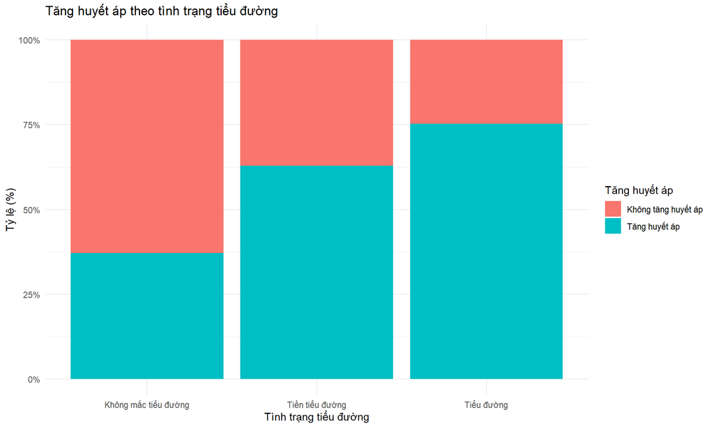

```r
ggplot(data, aes(x = diabetes_012, fill = factor(high_bp))) +
  geom_bar(position = "fill") +
  scale_y_continuous(labels = scales::percent) +
  scale_fill_discrete(labels = c("Không tăng huyết áp", "Tăng huyết áp")) +
  labs(title = "Tăng huyết áp theo tình trạng tiểu đường",
       x = "Tình trạng tiểu đường", y = "Tỷ lệ (%)", fill = "Tăng huyết áp") +
  theme_minimal()
```

**Nhận xét:**

- Tỷ lệ người có high_bp tăng rõ rệt ở nhóm tiền tiểu đường và tiểu đường.

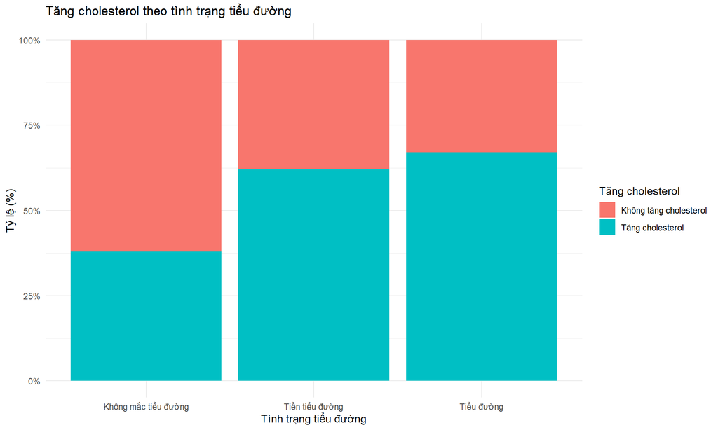

```r
ggplot(data, aes(x = diabetes_012, fill = factor(high_chol))) +
  geom_bar(position = "fill") +
  scale_y_continuous(labels = scales::percent) +
  scale_fill_discrete(labels = c("Không tăng cholesterol", "Tăng cholesterol")) +
  labs(title = "Tăng cholesterol theo tình trạng tiểu đường",
       x = "Tình trạng tiểu đường", y = "Tỷ lệ (%)", fill = "Tăng cholesterol") +
  theme_minimal()
```

**Nhận xét:**

- Người mắc/tiền mắc tiểu đường có tỷ lệ cholesterol cao hơn.

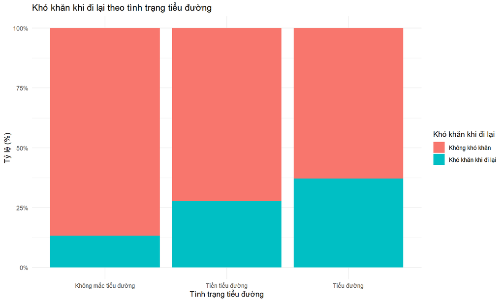

```r
ggplot(data, aes(x = diabetes_012, fill = factor(diff_walk))) +
  geom_bar(position = "fill") +
  scale_y_continuous(labels = scales::percent) +
  scale_fill_discrete(labels = c("Không khó khăn", "Khó khăn khi đi lại")) +
  labs(title = "Khó khăn khi đi lại theo tình trạng tiểu đường",
       x = "Tình trạng tiểu đường", y = "Tỷ lệ (%)", fill = "Khó khăn khi đi lại") +
  theme_minimal()
```

**Nhận xét:**

- Nhóm tiền/mắc tiểu đường có tỷ lệ gặp khó khăn khi đi lại cao hơn.
- Các biểu đồ tỷ lệ cho thấy sự khác biệt rõ rệt về phân bố của `high_bp`, `high_chol` và `diff_walk` giữa các nhóm tình trạng tiểu đường. Tỷ lệ cá nhân có huyết áp cao, cholesterol cao và gặp khó khăn khi đi lại tăng dần từ nhóm không tiểu đường sang tiền tiểu đường và tiểu đường, củng cố kết quả kiểm định Chi-square và Cramér’s V về vai trò dự báo quan trọng của các biến này.

### 3.4.4 Kruskal-Wallis test - Biến ordinal

```r
ordinal_vars_test <- c("age", "education", "income", "gen_hlth")

kw_result <- lapply(ordinal_vars_test, function(var) {
  test <- kruskal.test(as.formula(paste(var, "~ diabetes_012")), data = data)

  data.frame(
    variable = var,
    chi_square = as.numeric(test$statistic),
    df = test$parameter,
    p_value = test$p.value
  )
}) %>% bind_rows()

kable(kw_result,
      caption = "Kruskal-Wallis test - Biến ordinal vs Diabetes_012",
      digits = 4)
```

Kruskal-Wallis test - Biến ordinal vs Diabetes_012

|  | variable | chi_square | df | p_value |
| --- | --- | --- | --- | --- |
| df…1 | age | 8811.763 | 2 | 0 |
| df…2 | education | 4083.037 | 2 | 0 |
| df…3 | income | 7558.899 | 2 | 0 |
| df…4 | gen_hlth | 22480.925 | 2 | 0 |

```r
kw_effect <- data %>%
  select(diabetes_012, all_of(ordinal_vars_test)) %>%
  pivot_longer(-diabetes_012, names_to = "variable", values_to = "value") %>%
  group_by(variable) %>%
  kruskal_effsize(value ~ diabetes_012)

kable(kw_effect,
      caption = "Effect size (Eta-squared) - Biến ordinal",
      digits = 4)
```

Effect size (Eta-squared) - Biến ordinal

| variable | .y. | n | effsize | method | magnitude |
| --- | --- | --- | --- | --- | --- |
| age | value | 253680 | 0.0347 | eta2[H] | small |
| education | value | 253680 | 0.0161 | eta2[H] | small |
| gen_hlth | value | 253680 | 0.0886 | eta2[H] | moderate |
| income | value | 253680 | 0.0298 | eta2[H] | small |

**Nhận xét:**

Tất cả các biến ordinal đều khác biệt có ý nghĩa thống kê giữa các nhóm tình trạng tiểu đường (p < 0.001). Xét về mức độ ảnh hưởng, `gen_hlth` có ảnh hưởng trung bình (η² ≈ 0.089) và nổi bật hơn, cho thấy tình trạng sức khỏe tổng quát có mối liên hệ rõ rệt với tình trạng tiểu đường.

Trong khi đó, `age`, `education` và `income` có mức độ ảnh hưởng nhỏ (η² < 0.05), phản ánh vai trò phân biệt hạn chế hơn khi xét đơn lẻ, dù vẫn có ý nghĩa thống kê do kích thước mẫu lớn.

### 3.4.5 Visualization - Biến ordinal

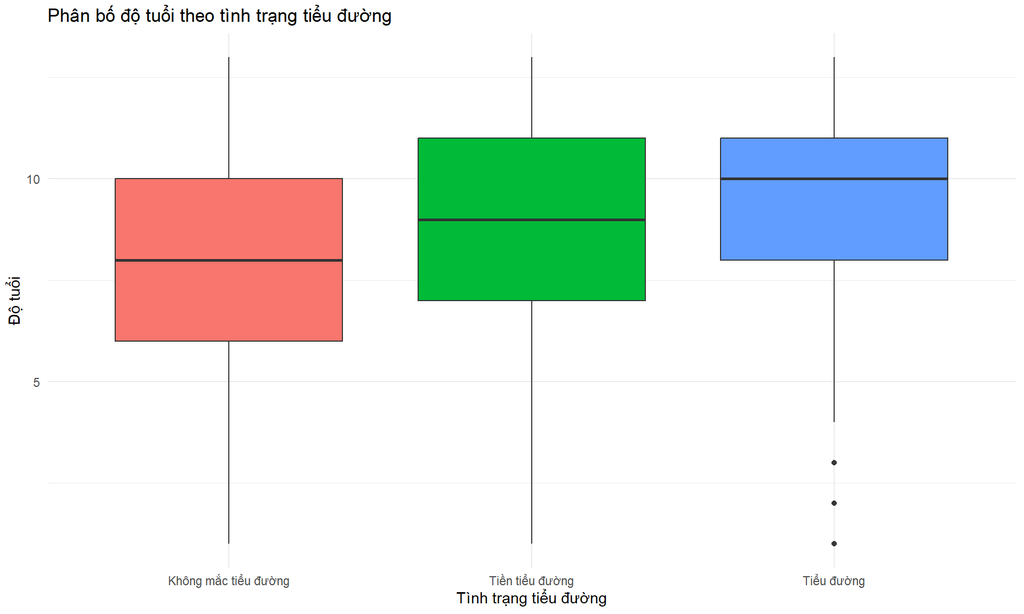

```r
ggplot(data, aes(x = diabetes_012, y = age, fill = diabetes_012)) +
  geom_boxplot(outlier.alpha = 0.1) +
  labs(title = "Phân bố độ tuổi theo tình trạng tiểu đường",
       x = "Tình trạng tiểu đường", y = "Độ tuổi") +
  theme_minimal() +
  theme(legend.position = "none")
```

**Nhận xét:**

- Tiểu đường tập trung ở độ tuổi trung niên và cao tuổi tuy nhiên 1 vài người trẻ vẫn bị.

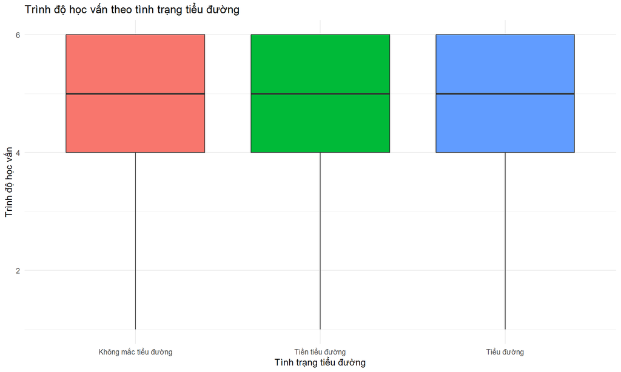

```r
ggplot(data, aes(x = diabetes_012, y = education, fill = diabetes_012)) +
  geom_boxplot(outlier.alpha = 0.1) +
  labs(title = "Trình độ học vấn theo tình trạng tiểu đường",
       x = "Tình trạng tiểu đường", y = "Trình độ học vấn") +
  theme_minimal() +
  theme(legend.position = "none")
```

**Nhận xét:**

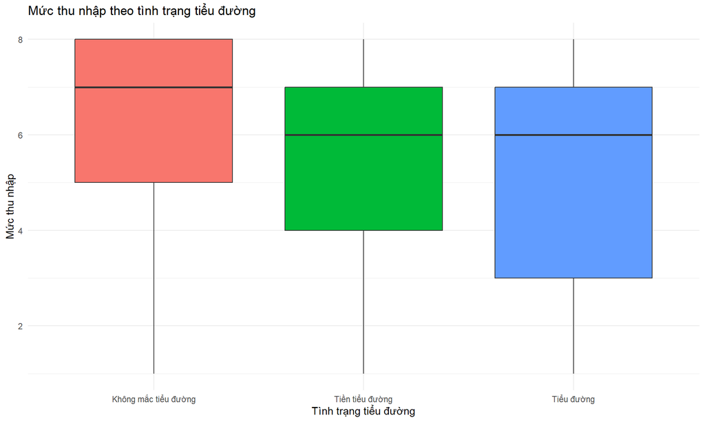

```r
ggplot(data, aes(x = diabetes_012, y = income, fill = diabetes_012)) +
  geom_boxplot(outlier.alpha = 0.1) +
  labs(title = "Mức thu nhập theo tình trạng tiểu đường",
       x = "Tình trạng tiểu đường", y = "Mức thu nhập") +
  theme_minimal() +
  theme(legend.position = "none")
```

**Nhận xét:**

- Nhóm không bị tiểu đường (No diabetes) có mức thu nhập trung vị cao hơn đáng kể so với hai nhóm còn lại. Trong khi đó, nhóm tiền tiểu đường và tiểu đường có mức thu nhập thấp hơn và phân phối khá tương đồng nhau.

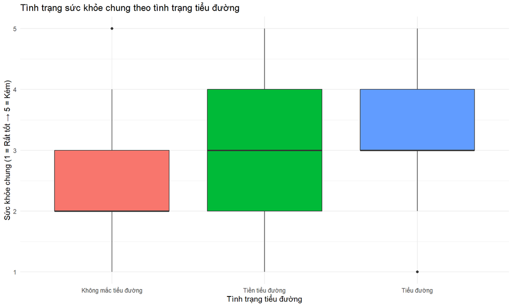

```r
ggplot(data, aes(x = diabetes_012, y = gen_hlth, fill = diabetes_012)) +
  geom_boxplot(outlier.alpha = 0.1) +
  labs(title = "Tình trạng sức khỏe chung theo tình trạng tiểu đường",
       x = "Tình trạng tiểu đường",
       y = "Sức khỏe chung (1 = Rất tốt → 5 = Kém)") +
  theme_minimal() +
  theme(legend.position = "none")
```

**Nhận xét:** Có xu hướng rõ ràng: tình trạng bệnh càng nặng thì tự đánh giá về sức khỏe càng kém.

### 3.4.6 Kruskal-Wallis test - Biến liên tục

```r
vars_cont <- c("bmi", "ment_hlth", "phys_hlth")

kw_results_cont <- lapply(vars_cont, function(v) {
  test <- kruskal.test(as.formula(paste(v, "~ diabetes_012")), data = data)
  data.frame(
    variable = v,
    chi_square = as.numeric(test$statistic),
    df = test$parameter,
    p_value = test$p.value
  )
})

kw_results_cont <- do.call(rbind, kw_results_cont)
kable(kw_results_cont,
      caption = "Kruskal-Wallis test - Biến liên tục vs Diabetes_012",
      digits = 4)
```

Kruskal-Wallis test - Biến liên tục vs Diabetes_012

|  | variable | chi_square | df | p_value |
| --- | --- | --- | --- | --- |
| df | bmi | 14130.7500 | 2 | 0 |
| df1 | ment_hlth | 528.9106 | 2 | 0 |
| df2 | phys_hlth | 6661.8780 | 2 | 0 |

**Nhận xét:**

Kiểm định Kruskal–Wallis cho thấy cả ba biến liên tục `bmi`, `ment_hlth`, `phys_hlth` đều khác biệt có ý nghĩa thống kê giữa các nhóm tình trạng tiểu đường (`diabetes_012`), với p-value ≪ 0.001.

- `bmi`: có sự khác biệt rất mạnh giữa các nhóm, cho thấy chỉ số BMI tăng rõ rệt theo mức độ tiểu đường → biến dự báo quan trọng.
- `phys_hlth`: số ngày sức khỏe thể chất kém khác nhau đáng kể giữa các nhóm, phản ánh gánh nặng sức khỏe tăng ở nhóm tiền tiểu đường và tiểu đường.
- `ment_hlth`: dù mức độ khác biệt nhỏ hơn hai biến còn lại, sự khác biệt vẫn có ý nghĩa thống kê, cho thấy yếu tố sức khỏe tinh thần cũng liên quan đến tình trạng tiểu đường.

### 3.4.7 Visualization - Biến liên tục

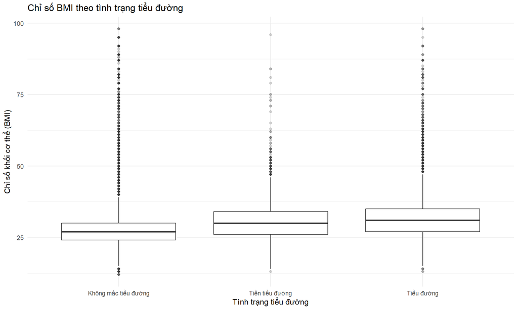

```r
ggplot(data, aes(x = diabetes_012, y = bmi)) +
  geom_boxplot(outlier.alpha = 0.2) +
  labs(title = "Chỉ số BMI theo tình trạng tiểu đường",
       x = "Tình trạng tiểu đường", y = "Chỉ số khối cơ thể (BMI)") +
  theme_minimal()
```

**Nhận xét:**

- Nhóm Tiểu đường và Tiền tiểu đường có mức BMI trung vị cao hơn một chút so với nhóm không bệnh.
- Cả 3 nhóm đều xuất hiện rất nhiều giá trị ngoại lai (outliers) ở mức BMI rất cao.

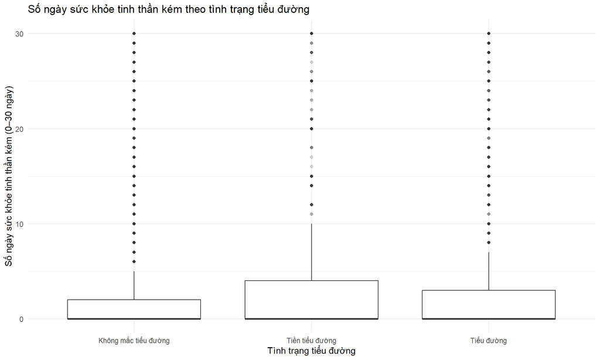

```r
ggplot(data, aes(x = diabetes_012, y = ment_hlth)) +
  geom_boxplot(outlier.alpha = 0.2) +
  labs(title = "Số ngày sức khỏe tinh thần kém theo tình trạng tiểu đường",
       x = "Tình trạng tiểu đường",
       y = "Số ngày sức khỏe tinh thần kém (0–30 ngày)") +
  theme_minimal()
```

**Nhận xét:**

- Dữ liệu bị lệch rất mạnh (Zero-inflated): Trung vị của cả 3 nhóm đều bằng 0, tức là đa số mọi người đều cảm thấy tinh thần bình thường (0 ngày kém).
- Tuy nhiên, nhóm Tiền tiểu đường có độ biến thiên (chiều cao hộp) lớn hơn, cho thấy một bộ phận trong nhóm này gặp nhiều vấn đề tâm lý hơn so với nhóm khỏe mạnh.

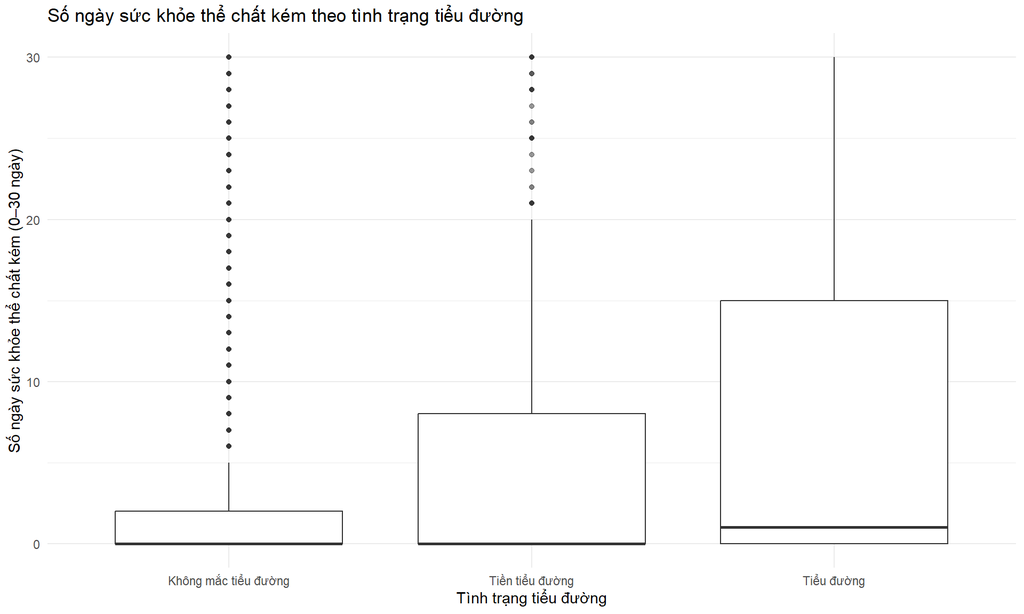

```r
ggplot(data, aes(x = diabetes_012, y = phys_hlth)) +
  geom_boxplot(outlier.alpha = 0.2) +
  labs(title = "Số ngày sức khỏe thể chất kém theo tình trạng tiểu đường",
       x = "Tình trạng tiểu đường",
       y = "Số ngày sức khỏe thể chất kém (0–30 ngày)") +
  theme_minimal()
```

**Nhận xét:**

- Nhóm Tiểu đường có phân phối trải rộng hơn hẳn (hộp rất dài, kéo đến 15 ngày), chứng tỏ người bệnh tiểu đường chịu ảnh hưởng nặng nề về thể chất hàng ngày hơn rất nhiều so với hai nhóm còn lại.

# 4 Phân tích tương quan và đa cộng tuyến

## 4.1 Correlation Analysis

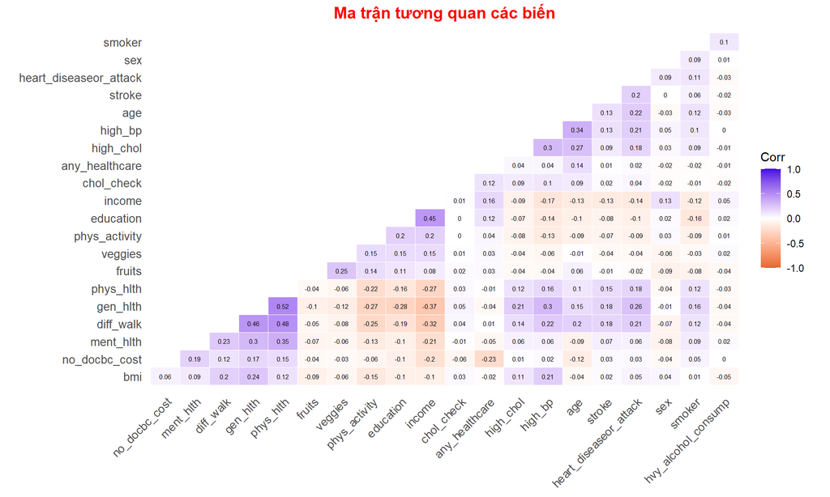

```r
# Tạo ma trận tương quan
cor_matrix <- cor(data %>% select(-diabetes_012))

# Vẽ heatmap
ggcorrplot(cor_matrix,
           hc.order = TRUE,
           type = "lower",
           outline.col = "white",
           ggtheme = ggplot2::theme_minimal(),
           colors = c("#E4672E", "white", "#3F09E0"),
           lab = TRUE,
           title = "Ma trận tương quan các biến",
           lab_size = 2) +
  labs(x = NULL, y = NULL) +
  theme(
    axis.text.y = element_text(size = 10, vjust = 0.5),
    axis.text.x = element_text(size = 10),
    plot.title = element_text(color = "red", size = 14, face = "bold", hjust = 0.5),
    panel.grid = element_blank()
  ) +
  coord_fixed(ratio = 0.6) +
  scale_y_discrete(expand = expansion(add = 0.8))
```

## 4.2 Nhận xét về mối tương quan

### 4.2.1 Các nhân tố dự báo mạnh nhất:

- **Sức khỏe tổng quát (gen_hlth)** có tương quan thuận mạnh nhất (0.30). Theo danh mục tra cứu (column 90): điểm đánh giá được xếp từ 1-5 (theo thứ tự từ khỏe → yếu, 7 là không biết và 9 là từ chối trả lời). Điều này có nghĩa là khi điểm tự đánh giá sức khỏe càng cao (sức khỏe tệ), nguy cơ mắc tiểu đường càng cao.
- **Chỉ số thể trạng (bmi)** với hệ số tương quan 0.22 cho thấy đây là tiền đề thể chất dẫn đến tiểu đường. Vì: Lượng mỡ thừa giải phóng các acid béo tự do và các chất gây viêm (cytokine như TNF-alpha) làm giảm độ nhạy của các thụ thể insulin trên tế bào, dẫn đến tình trạng kháng insulin. Khi tế bào không hấp thụ được đường, tuyến tụy phải làm việc quá tải và suy yếu, gây ra tiểu đường Type 2. Theo Tổ chức Y tế Thế giới (WHO) và Hiệp hội Đái tháo đường Hoa Kỳ (ADA), người có chỉ số BMI > 30 có nguy cơ mắc tiểu đường cao gấp 20 đến 40 lần so với người có cân nặng bình thường.
- **Huyết áp cao (high_bp)**, **Cholesterol cao (high_chol)**, **bệnh tim hoặc nhồi máu cơ tim (heart_diseaseor_attack)** là các yếu tố lâm sàng quan trọng tiếp theo (0.27, 0.21 và 0.18). Điều này hoàn toàn đúng với y học: béo phì và cao huyết áp là các tiền đề trực tiếp của tiểu đường.
  - Tiểu đường: Cao huyết áp gây áp lực lớn lên thành mạch, làm tổn thương lớp nội mạc. Tình trạng này kết hợp với lượng đường huyết cao sẽ đẩy nhanh quá trình xơ vữa động mạch và làm trầm trọng thêm tình trạng kháng insulin. Nghiên cứu từ American Journal of Hypertension cho thấy khoảng 50-80% bệnh nhân tiểu đường Type 2 cũng bị cao huyết áp đồng thời.
  - Cholesterol cao: Tương quan thuận đáng kể vì rối loạn lipid máu thường đi kèm với rối loạn chuyển hóa đường.
  - Bệnh tim và Nhồi máu cơ tim: Khi hệ thống mạch máu bị tổn thương bởi Huyết áp cao và Cholesterol cao, lưu lượng máu đến cơ tim bị cản trở, dẫn đến các cơn nhồi máu cơ tim. Theo CDC, người mắc tiểu đường có nguy cơ tử vong vì bệnh tim cao gấp 2 lần người bình thường.
- **Các biến số về sự suy giảm vận động (diff_walk, phys_hlth)**: Tương quan thuận (0.22 và 0.18) cho thấy tiểu đường thường đi kèm với các biến chứng về thần kinh ngoại biên hoặc xương khớp, làm hạn chế khả năng di chuyển và tăng số ngày có sức khỏe kém trong tháng.
- **Tuổi tác (age)**: Tương quan thuận (0.19) phản ánh quy luật sinh học khi tuổi thọ tăng, hiệu suất chuyển hóa của tuyến tụy giảm dần và các tổn thương tế bào tích lũy dẫn đến nguy cơ bùng phát bệnh cao hơn ở người trung niên và người già.

### 4.2.2 Nhân tố bảo vệ (Tương quan nghịch):

- **Thu nhập (income)** và **Học vấn (education)** có tương quan nghịch mạnh nhất với tiểu đường (-0.17 và -0.13) cho thấy những người có thu nhập và học vấn cao hơn thường có lối sống lành mạnh hơn, tiếp cận thực phẩm dinh dưỡng, kiến thức phòng bệnh cũng như hệ thống y tế tốt hơn, dẫn đến tỉ lệ mắc bệnh thấp hơn.
- **Hoạt động thể chất (phys_activity)** cũng cho thấy tác động giảm thiểu nguy cơ rõ rệt với hệ số tương quan -0.12; khẳng định việc vận động giúp cơ bắp tiêu thụ glucose hiệu quả hơn, làm giảm nồng độ đường trong máu một cách tự nhiên.

## 4.3 Multicollinearity (VIF)

```r
# Tạo mô hình tuyến tính tạm để tính VIF
data_numeric <- data
data_numeric$diabetes_012_num <- as.numeric(data$diabetes_012)

model_vif <- lm(diabetes_012_num ~ . - diabetes_012, data = data_numeric)

vif_results <- vif(model_vif)

vif_df <- data.frame(
  Variable = names(vif_results),
  VIF = as.numeric(vif_results)
)

vif_df <- vif_df[order(-vif_df$VIF), ]

kable(head(vif_df, 15),
      caption = "Top 15 biến có VIF cao nhất",
      row.names = FALSE,
      digits = 3)
```

Top 15 biến có VIF cao nhất

| Variable | VIF |
| --- | --- |
| gen_hlth | 1.796 |
| phys_hlth | 1.623 |
| diff_walk | 1.534 |
| income | 1.504 |
| age | 1.350 |
| high_bp | 1.331 |
| education | 1.326 |
| ment_hlth | 1.239 |
| high_chol | 1.173 |
| heart_diseaseor_attack | 1.172 |
| phys_activity | 1.157 |
| no_docbc_cost | 1.144 |
| bmi | 1.140 |
| any_healthcare | 1.113 |
| fruits | 1.113 |

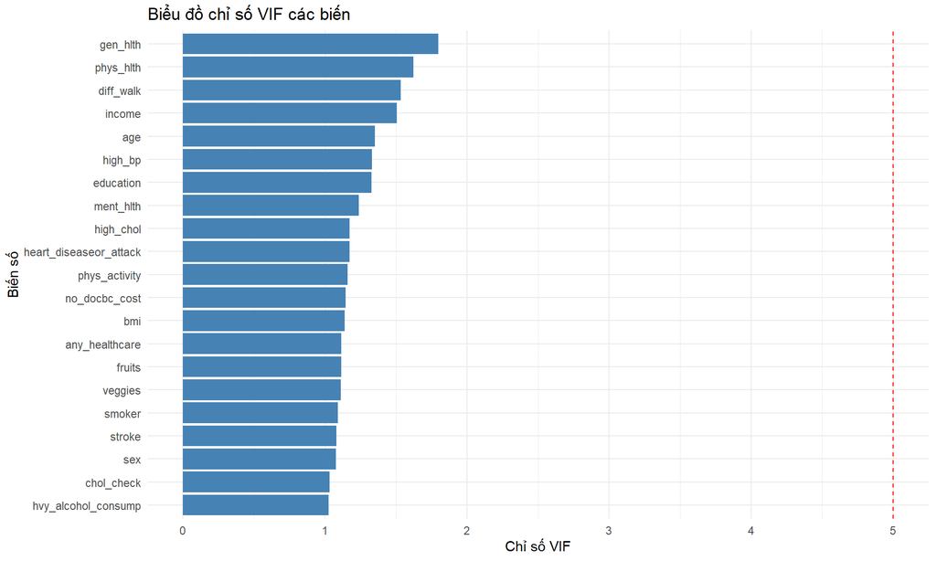

```r
ggplot(vif_df, aes(x = reorder(Variable, VIF), y = VIF)) +
  geom_bar(stat = "identity", fill = "steelblue") +
  geom_hline(yintercept = 5, linetype = "dashed", color = "red") +
  coord_flip() +
  labs(title = "Biểu đồ chỉ số VIF các biến",
       x = "Biến số", y = "Chỉ số VIF") +
  theme_minimal()
```

**Nhận xét:**

Tất cả các biến đều có VIF < 2, cho thấy không tồn tại đa cộng tuyến nghiêm trọng. Mô hình đảm bảo tính ổn định của các hệ số hồi quy và cho phép tin tưởng vào kết luận về tác động riêng biệt của từng nhân tố.

## 4.4 Kết luận EDA

Mối quan hệ đa biến rõ ràng, không bị nhiễu bởi đa cộng tuyến nghiêm trọng. Tiểu đường trong tập dữ liệu này bị chi phối bởi 3 nhóm chính:

1. **Thể trạng lâm sàng** (bmi, high_bp)
2. **Cảm quan sức khỏe** (gen_hlth)
3. **Điều kiện kinh tế xã hội** (income, education)

# 5 Tiền xử lý dữ liệu (Data Preprocessing)

## 5.1 Kiểm tra Missing Values

```r
missing_counts <- colSums(is.na(data))
missing_pct <- round(100 * missing_counts / nrow(data), 2)

missing_summary <- data.frame(
  Variable = names(missing_counts),
  Missing_Count = missing_counts,
  Missing_Pct = missing_pct
)

kable(missing_summary[missing_summary$Missing_Count > 0, ],
      caption = "Missing Values Summary",
      row.names = FALSE)
```

Missing Values Summary

| Variable | Missing_Count | Missing_Pct |
| --- | --- | --- |

**Kết quả:** Không có missing values trong dataset.

## 5.2 Chuẩn bị dữ liệu cho mô hình

```r
# Tạo bản sao để xử lý
data_scaled <- data

# Chuẩn hóa các biến continuous bằng z-score
for (var in continuous_vars) {
  data_scaled[[var]] <- scale(data_scaled[[var]])[, 1]
}

# Kiểm tra kết quả chuẩn hóa
cat("Mean and SD after scaling:\n")
```

```
## Mean and SD after scaling:
```

```r
sapply(data_scaled[, continuous_vars], function(x) c(mean = mean(x), sd = sd(x)))
```

```
##                bmi     ment_hlth    phys_hlth
## mean -2.535288e-16 -7.105779e-18 7.569019e-17
## sd    1.000000e+00  1.000000e+00 1.000000e+00
```

**Lý do chuẩn hóa:** LDA tính toán ma trận covariance chung. Nếu các biến có scale khác nhau nhiều, biến có phương sai lớn hơn sẽ chi phối discriminant function.

```r
# Loại các biến có phương sai thấp
data_final <- data_scaled %>%
  select(-c(chol_check, any_healthcare, no_docbc_cost))

cat("✓ Data ready for modeling\n")
```

```
## ✓ Data ready for modeling
```

```r
cat("Number of observations:", nrow(data_final), "\n")
```

```
## Number of observations: 253680
```

```r
cat("Number of features:", ncol(data_final) - 1, "(excluding target)\n")
```

```
## Number of features: 18 (excluding target)
```

# 6 Phương pháp mô hình hóa

## 6.1 Multinomial Logistic Regression

### 6.1.1 Tại sao chọn Multinomial Logistic Regression?

**Multinomial Logistic Regression (MLR)** là mô hình phân loại tuyến tính mở rộng cho bài toán đa lớp. MLR được chọn làm **baseline model** vì:

1. **Phù hợp với biến mục tiêu nominal đa lớp** - sử dụng softmax function
2. **Dễ diễn giải** - hệ số hồi quy cho phép diễn giải log-odds ratio
3. **Baseline để so sánh** với các mô hình phức tạp hơn
4. **Robust** với dữ liệu có nhiều biến nhị phân và ordinal

### 6.1.2 Kiểm tra giả định MLR

```r
cat("=== KIỂM TRA GIẢ ĐỊNH MULTINOMIAL LOGISTIC REGRESSION ===\n\n")
```

```
## === KIỂM TRA GIẢ ĐỊNH MULTINOMIAL LOGISTIC REGRESSION ===
```

```r
# Giả định 1: Biến phụ thuộc là nominal (categorical) với > 2 lớp
cat("✓ Giả định 1: Biến phụ thuộc Diabetes_012 là nominal với 3 lớp\n")
```

```
## ✓ Giả định 1: Biến phụ thuộc Diabetes_012 là nominal với 3 lớp
```

```r
cat("  Levels:", paste(levels(data_final$diabetes_012), collapse = ", "), "\n\n")
```

```
##   Levels: Không mắc tiểu đường, Tiền tiểu đường, Tiểu đường
```

```r
# Giả định 2: Các quan sát độc lập (independent observations)
cat("✓ Giả định 2: Dữ liệu từ BRFSS survey, mỗi người được khảo sát 1 lần\n")
```

```
## ✓ Giả định 2: Dữ liệu từ BRFSS survey, mỗi người được khảo sát 1 lần
```

```r
cat("  → Quan sát độc lập\n\n")
```

```
##   → Quan sát độc lập
```

```r
# Giả định 3: Không có đa cộng tuyến nghiêm trọng (no severe multicollinearity)
cat("✓ Giả định 3: Không có đa cộng tuyến nghiêm trọng\n")
```

```
## ✓ Giả định 3: Không có đa cộng tuyến nghiêm trọng
```

```r
cat("  Tất cả VIF < 2 (đã kiểm tra ở phần VIF Analysis)\n")
```

```
##   Tất cả VIF < 2 (đã kiểm tra ở phần VIF Analysis)
```

```r
cat("  → Ma trận Hessian có thể được tính toán ổn định\n\n")
```

```
##   → Ma trận Hessian có thể được tính toán ổn định
```

```r
# Giả định 4: Kích thước mẫu đủ lớn
n_obs <- nrow(data_final)
n_predictors <- ncol(data_final) - 1
min_required <- 10 * n_predictors  # Rule of thumb: ≥ 10-15 obs per predictor

cat("✓ Giả định 4: Kích thước mẫu đủ lớn\n")
```

```
## ✓ Giả định 4: Kích thước mẫu đủ lớn
```

```r
cat("  Số quan sát:", n_obs, "\n")
```

```
##   Số quan sát: 253680
```

```r
cat("  Số predictors:", n_predictors, "\n")
```

```
##   Số predictors: 18
```

```r
cat("  Yêu cầu tối thiểu (10× rule):", min_required, "\n")
```

```
##   Yêu cầu tối thiểu (10× rule): 180
```

```r
cat("  → Kích thước mẫu vượt xa yêu cầu\n\n")
```

```
##   → Kích thước mẫu vượt xa yêu cầu
```

```r
cat("=== TÓM TẮT KIỂM TRA GIẢ ĐỊNH ===\n")
```

```
## === TÓM TẮT KIỂM TRA GIẢ ĐỊNH ===
```

```r
cat("✓ Biến phụ thuộc nominal (3 lớp): Thỏa mãn\n")
```

```
## ✓ Biến phụ thuộc nominal (3 lớp): Thỏa mãn
```

```r
cat("✓ Quan sát độc lập: Thỏa mãn\n")
```

```
## ✓ Quan sát độc lập: Thỏa mãn
```

```r
cat("✓ Không có đa cộng tuyến nghiêm trọng: Thỏa mãn (VIF < 2)\n")
```

```
## ✓ Không có đa cộng tuyến nghiêm trọng: Thỏa mãn (VIF < 2)
```

```r
cat("✓ Kích thước mẫu đủ lớn: Thỏa mãn\n\n")
```

```
## ✓ Kích thước mẫu đủ lớn: Thỏa mãn
```

```r
cat("→ KẾT LUẬN: Multinomial Logistic Regression có thể áp dụng\n")
```

```
## → KẾT LUẬN: Multinomial Logistic Regression có thể áp dụng
```

```r
cat("   Lưu ý: Class imbalance sẽ được xử lý bằng hybrid approach\n")
```

```
##    Lưu ý: Class imbalance sẽ được xử lý bằng hybrid approach
```

### 6.1.3 Feature Selection

```r
# Tạo biến numeric để tính correlation
data_for_corr <- data_final
data_for_corr$diabetes_numeric <- as.numeric(data_for_corr$diabetes_012) - 1

# Tính correlation
correlations <- sapply(names(data_for_corr)[!names(data_for_corr) %in%
                       c("diabetes_012", "diabetes_numeric")], function(var) {
  cor(data_for_corr[[var]], data_for_corr$diabetes_numeric, use = "complete.obs")
})

cor_df <- data.frame(
  Variable = names(correlations),
  Correlation = correlations
) %>% arrange(desc(abs(Correlation)))

# Chọn top 10 features
important_features <- cor_df$Variable[1:10]
cat("✓ Chọn 10 features:", paste(important_features, collapse = ", "), "\n")
```

```
## ✓ Chọn 10 features: gen_hlth, high_bp, bmi, diff_walk, high_chol, age, heart_diseaseor_attack, phys_hlth, income, education
```

```r
# Dataset với features đã chọn
data_selected <- data_final %>%
  select(diabetes_012, all_of(important_features))
```

### 6.1.4 Train/Test Split

```r
set.seed(2024)

train_index_mlr <- createDataPartition(
  data_selected$diabetes_012,
  p = 0.7,
  list = FALSE
)

train_data_mlr <- data_selected[train_index_mlr, ]
test_data_mlr <- data_selected[-train_index_mlr, ]

cat("Train:", nrow(train_data_mlr), "samples\n")
```

```
## Train: 177578 samples
```

```r
cat("Test:", nrow(test_data_mlr), "samples\n")
```

```
## Test: 76102 samples
```

### 6.1.5 Hybrid Model (Undersampling + SMOTE + Class Weights)

```r
# Undersampling
class_0_mlr <- train_data_mlr[train_data_mlr$diabetes_012 == "Không mắc tiểu đường", ]
class_1_mlr <- train_data_mlr[train_data_mlr$diabetes_012 == "Tiền tiểu đường", ]
class_2_mlr <- train_data_mlr[train_data_mlr$diabetes_012 == "Tiểu đường", ]

target_majority <- round(nrow(class_2_mlr) * 3)
class_0_reduced <- class_0_mlr[sample(nrow(class_0_mlr),
                                      min(target_majority, nrow(class_0_mlr))), ]

train_before_smote_mlr <- rbind(class_0_reduced, class_1_mlr, class_2_mlr)

# SMOTE
train_before_smote_mlr$diabetes_012_num <- as.numeric(train_before_smote_mlr$diabetes_012) - 1
X_hybrid_mlr <- train_before_smote_mlr[, -which(names(train_before_smote_mlr) %in%
                                          c("diabetes_012", "diabetes_012_num"))]
y_hybrid_mlr <- train_before_smote_mlr$diabetes_012_num

smote_hybrid_mlr <- SMOTE(X = X_hybrid_mlr, target = y_hybrid_mlr, K = 5, dup_size = 0)

train_hybrid_mlr <- smote_hybrid_mlr$data
colnames(train_hybrid_mlr)[ncol(train_hybrid_mlr)] <- "diabetes_012"

train_hybrid_mlr$diabetes_012 <- factor(
  train_hybrid_mlr$diabetes_012,
  levels = c(0, 1, 2),
  labels = c("Không mắc tiểu đường", "Tiền tiểu đường", "Tiểu đường")
)

# Class weights
class_weights_hybrid_mlr <- c("Không mắc tiểu đường" = 1,
                              "Tiền tiểu đường" = 0.8,
                              "Tiểu đường" = 3.8)
model_weights_mlr <- class_weights_hybrid_mlr[as.character(train_hybrid_mlr$diabetes_012)]

# Train model
logit_hybrid_mlr <- multinom(
  diabetes_012 ~ .,
  data = train_hybrid_mlr,
  weights = model_weights_mlr,
  trace = FALSE,
  maxit = 200
)

# Predict
pred_hybrid_mlr <- predict(logit_hybrid_mlr, newdata = test_data_mlr, type = "class")
conf_hybrid_mlr <- confusionMatrix(pred_hybrid_mlr, test_data_mlr$diabetes_012)

cat("\n=== HYBRID MODEL RESULTS ===\n")
```

```
##
## === HYBRID MODEL RESULTS ===
```

```r
print(conf_hybrid_mlr$table)
```

```
##                       Reference
## Prediction             Không mắc tiểu đường Tiền tiểu đường Tiểu đường
##   Không mắc tiểu đường                40885             368       1645
##   Tiền tiểu đường                      8310             268       1547
##   Tiểu đường                          14915             753       7411
```

```r
cat("\nSensitivity:\n")
```

```
##
## Sensitivity:
```

```r
print(round(conf_hybrid_mlr$byClass[, "Sensitivity"], 4))
```

```
## Class: Không mắc tiểu đường      Class: Tiền tiểu đường
##                      0.6377                      0.1929
##           Class: Tiểu đường
##                      0.6990
```

### 6.1.6 ROC Curves - MLR

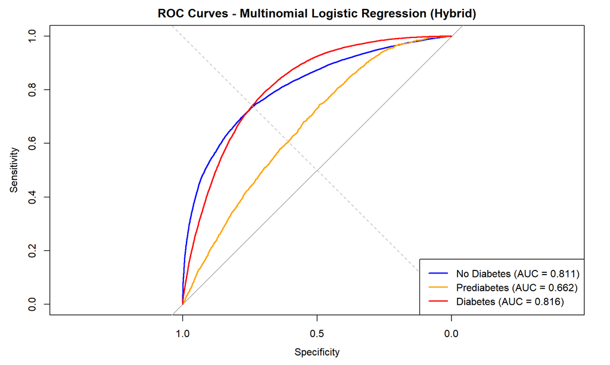

```r
# Probabilities
prob_hybrid_mlr <- predict(logit_hybrid_mlr, newdata = test_data_mlr, type = "probs")

# Binary labels
test_binary_0_mlr <- ifelse(test_data_mlr$diabetes_012 == "Không mắc tiểu đường", 1, 0)
test_binary_1_mlr <- ifelse(test_data_mlr$diabetes_012 == "Tiền tiểu đường", 1, 0)
test_binary_2_mlr <- ifelse(test_data_mlr$diabetes_012 == "Tiểu đường", 1, 0)

# ROC curves
roc_0_mlr <- roc(test_binary_0_mlr, prob_hybrid_mlr[, 1], quiet = TRUE)
roc_1_mlr <- roc(test_binary_1_mlr, prob_hybrid_mlr[, 2], quiet = TRUE)
roc_2_mlr <- roc(test_binary_2_mlr, prob_hybrid_mlr[, 3], quiet = TRUE)

# Plot
plot(roc_0_mlr, col = "blue", lwd = 2,
     main = "ROC Curves - Multinomial Logistic Regression (Hybrid)")
plot(roc_1_mlr, col = "orange", lwd = 2, add = TRUE)
plot(roc_2_mlr, col = "red", lwd = 2, add = TRUE)
abline(a = 0, b = 1, lty = 2, col = "gray")

legend("bottomright",
       legend = c(
         paste0("No Diabetes (AUC = ", round(auc(roc_0_mlr), 3), ")"),
         paste0("Prediabetes (AUC = ", round(auc(roc_1_mlr), 3), ")"),
         paste0("Diabetes (AUC = ", round(auc(roc_2_mlr), 3), ")")
       ),
       col = c("blue", "orange", "red"),
       lwd = 2)
```

## 6.2 Linear Discriminant Analysis (LDA)

### 6.2.1 Tại sao chọn LDA?

**Linear Discriminant Analysis** là một kỹ thuật phân loại thống kê cổ điển, đặc biệt phù hợp cho bài toán phân loại đa lớp trong lĩnh vực y sinh vì:

1. **Generative Model** với nền tảng xác suất vững chắc
2. **Phù hợp cho phân loại đa lớp** (K > 2)
3. **Giảm chiều dữ liệu** (Dimensionality Reduction)
4. **Baseline model dễ diễn giải** trong y sinh

### 6.2.2 Kiểm tra giả định LDA

```r
cat("=== KIỂM TRA GIẢ ĐỊNH LINEAR DISCRIMINANT ANALYSIS ===\n\n")
```

```
## === KIỂM TRA GIẢ ĐỊNH LINEAR DISCRIMINANT ANALYSIS ===
```

```r
# Giả định 1: Phân phối Gaussian đa biến (Multivariate Normality)
cat("Giả định 1: Phân phối Gaussian đa biến trong mỗi lớp\n")
```

```
## Giả định 1: Phân phối Gaussian đa biến trong mỗi lớp
```

```r
cat("  Kiểm tra trực quan (đã thực hiện ở phần EDA):\n")
```

```
##   Kiểm tra trực quan (đã thực hiện ở phần EDA):
```

```r
cat("  - BMI: Phân phối lệch phải nhẹ, có đỉnh rõ ràng\n")
```

```
##   - BMI: Phân phối lệch phải nhẹ, có đỉnh rõ ràng
```

```r
cat("  - Age: Biến ordinal rời rạc, xấp xỉ liên tục do mẫu lớn\n")
```

```
##   - Age: Biến ordinal rời rạc, xấp xỉ liên tục do mẫu lớn
```

```r
cat("  - GenHlth: Biến ordinal (1-5), không hoàn toàn Gaussian\n")
```

```
##   - GenHlth: Biến ordinal (1-5), không hoàn toàn Gaussian
```

```r
cat("  ⚠ Giả định NORMALITY bị vi phạm nhẹ, nhưng chấp nhận được\n")
```

```
##   ⚠ Giả định NORMALITY bị vi phạm nhẹ, nhưng chấp nhận được
```

```r
cat("    với dữ liệu y sinh có nhiều biến nhị phân và ordinal\n\n")
```

```
##     với dữ liệu y sinh có nhiều biến nhị phân và ordinal
```

```r
# Giả định 2: Ma trận hiệp phương sai đồng nhất (Homogeneity of Covariance)
cat("Giả định 2: Ma trận hiệp phương sai đồng nhất giữa các lớp\n")
```

```
## Giả định 2: Ma trận hiệp phương sai đồng nhất giữa các lớp
```

```r
cat("  Kiểm định: Box's M-test\n")
```

```
##   Kiểm định: Box's M-test
```

```r
X <- data_final[, !(names(data_final) %in% "diabetes_012")]
Y <- data_final$diabetes_012
box_m <- boxM(X, Y)

cat("  Chi-square statistic:", round(box_m$statistic, 2), "\n")
```

```
##   Chi-square statistic: 90224.61
```

```r
cat("  p-value: < 2.2e-16\n")
```

```
##   p-value: < 2.2e-16
```

```r
cat("  ⚠ Giả định HOMOGENEITY OF COVARIANCE bị vi phạm (p < 0.001)\n")
```

```
##   ⚠ Giả định HOMOGENEITY OF COVARIANCE bị vi phạm (p < 0.001)
```

```r
cat("\n  Giải thích:\n")
```

```
##
##   Giải thích:
```

```r
cat("  - Box's M-test rất nhạy với kích thước mẫu lớn\n")
```

```
##   - Box's M-test rất nhạy với kích thước mẫu lớn
```

```r
cat("  - Vi phạm này là phổ biến trong dữ liệu y sinh thực tế\n")
```

```
##   - Vi phạm này là phổ biến trong dữ liệu y sinh thực tế
```

```r
cat("  - Dẫn đến: LDA kém robust, có thể bias về lớp đa số\n")
```

```
##   - Dẫn đến: LDA kém robust, có thể bias về lớp đa số
```

```r
cat("  - Giải pháp: Dùng balanced prior và so sánh với QDA/XGBoost\n\n")
```

```
##   - Giải pháp: Dùng balanced prior và so sánh với QDA/XGBoost
```

```r
# Giả định 3: Không có đa cộng tuyến nghiêm trọng
cat("✓ Giả định 3: Không có đa cộng tuyến nghiêm trọng\n")
```

```
## ✓ Giả định 3: Không có đa cộng tuyến nghiêm trọng
```

```r
cat("  Tất cả VIF < 2 (đã kiểm tra ở phần VIF Analysis)\n")
```

```
##   Tất cả VIF < 2 (đã kiểm tra ở phần VIF Analysis)
```

```r
cat("  → Ma trận covariance có thể được ước lượng ổn định\n\n")
```

```
##   → Ma trận covariance có thể được ước lượng ổn định
```

```r
# Giả định 4: Quan sát độc lập
cat("✓ Giả định 4: Các quan sát độc lập\n")
```

```
## ✓ Giả định 4: Các quan sát độc lập
```

```r
cat("  Dữ liệu từ BRFSS cross-sectional survey\n")
```

```
##   Dữ liệu từ BRFSS cross-sectional survey
```

```r
cat("  → Không có cấu trúc phụ thuộc (clustered/longitudinal)\n\n")
```

```
##   → Không có cấu trúc phụ thuộc (clustered/longitudinal)
```

```r
cat("=== TÓM TẮT KIỂM TRA GIẢ ĐỊNH ===\n")
```

```
## === TÓM TẮT KIỂM TRA GIẢ ĐỊNH ===
```

```r
cat("⚠ Giả định 1 (Multivariate Normality): Vi phạm nhẹ, chấp nhận được\n")
```

```
## ⚠ Giả định 1 (Multivariate Normality): Vi phạm nhẹ, chấp nhận được
```

```r
cat("⚠ Giả định 2 (Homogeneity of Covariance): Vi phạm nghiêm trọng\n")
```

```
## ⚠ Giả định 2 (Homogeneity of Covariance): Vi phạm nghiêm trọng
```

```r
cat("✓ Giả định 3 (No Multicollinearity): Thỏa mãn (VIF < 2)\n")
```

```
## ✓ Giả định 3 (No Multicollinearity): Thỏa mãn (VIF < 2)
```

```r
cat("✓ Giả định 4 (Independence): Thỏa mãn\n\n")
```

```
## ✓ Giả định 4 (Independence): Thỏa mãn
```

```r
cat("→ KẾT LUẬN:\n")
```

```
## → KẾT LUẬN:
```

```r
cat("  LDA vi phạm giả định quan trọng về covariance matrix\n")
```

```
##   LDA vi phạm giả định quan trọng về covariance matrix
```

```r
cat("  → Sử dụng LDA như BASELINE MODEL để so sánh\n")
```

```
##   → Sử dụng LDA như BASELINE MODEL để so sánh
```

```r
cat("  → Kỳ vọng XGBoost (phi tham số) sẽ vượt trội hơn\n")
```

```
##   → Kỳ vọng XGBoost (phi tham số) sẽ vượt trội hơn
```

### 6.2.3 Train/Test Split

```r
set.seed(2024)

train_index <- createDataPartition(
  data_final$diabetes_012,
  p = 0.7,
  list = FALSE,
  times = 1
)

train_data <- data_final[train_index, ]
test_data <- data_final[-train_index, ]

cat("Train distribution:\n")
```

```
## Train distribution:
```

```r
print(table(train_data$diabetes_012))
```

```
##
## Không mắc tiểu đường      Tiền tiểu đường           Tiểu đường
##               149593                 3242                24743
```

```r
cat("\nTest distribution:\n")
```

```
##
## Test distribution:
```

```r
print(table(test_data$diabetes_012))
```

```
##
## Không mắc tiểu đường      Tiền tiểu đường           Tiểu đường
##                64110                 1389                10603
```

### 6.2.4 LDA Model với Balanced Prior

```r
# LDA với balanced prior
lda_model_balanced <- lda(
  diabetes_012 ~ .,
  data = train_data,
  prior = c(1/3, 1/3, 1/3)
)

# Predict
lda_pred_balanced <- predict(lda_model_balanced, newdata = test_data)

# Confusion matrix
conf_matrix_balanced <- confusionMatrix(
  data = lda_pred_balanced$class,
  reference = test_data$diabetes_012
)

cat("=== LDA WITH BALANCED PRIOR ===\n")
```

```
## === LDA WITH BALANCED PRIOR ===
```

```r
print(conf_matrix_balanced$table)
```

```
##                       Reference
## Prediction             Không mắc tiểu đường Tiền tiểu đường Tiểu đường
##   Không mắc tiểu đường                42661             406       1865
##   Tiền tiểu đường                     12135             486       3398
##   Tiểu đường                           9314             497       5340
```

```r
cat("\nSensitivity:\n")
```

```
##
## Sensitivity:
```

```r
print(round(conf_matrix_balanced$byClass[, "Sensitivity"], 4))
```

```
## Class: Không mắc tiểu đường      Class: Tiền tiểu đường
##                      0.6654                      0.3499
##           Class: Tiểu đường
##                      0.5036
```

### 6.2.5 ROC Curves - LDA

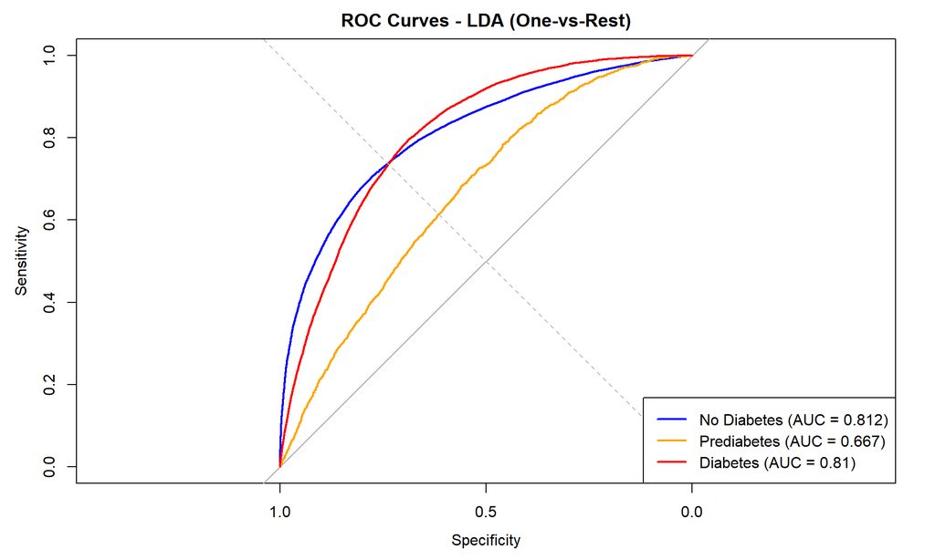

```r
# Binary labels
test_binary_0 <- ifelse(test_data$diabetes_012 == "Không mắc tiểu đường", 1, 0)
test_binary_1 <- ifelse(test_data$diabetes_012 == "Tiền tiểu đường", 1, 0)
test_binary_2 <- ifelse(test_data$diabetes_012 == "Tiểu đường", 1, 0)

prob_0 <- lda_pred_balanced$posterior[, "Không mắc tiểu đường"]
prob_1 <- lda_pred_balanced$posterior[, "Tiền tiểu đường"]
prob_2 <- lda_pred_balanced$posterior[, "Tiểu đường"]

# ROC curves
roc_0 <- roc(test_binary_0, prob_0, quiet = TRUE)
roc_1 <- roc(test_binary_1, prob_1, quiet = TRUE)
roc_2 <- roc(test_binary_2, prob_2, quiet = TRUE)

# Plot
plot(roc_0, col = "blue", lwd = 2, main = "ROC Curves - LDA (One-vs-Rest)")
plot(roc_1, col = "orange", lwd = 2, add = TRUE)
plot(roc_2, col = "red", lwd = 2, add = TRUE)
abline(a = 0, b = 1, lty = 2, col = "gray")
legend("bottomright",
       legend = c(
         paste0("No Diabetes (AUC = ", round(auc(roc_0), 3), ")"),
         paste0("Prediabetes (AUC = ", round(auc(roc_1), 3), ")"),
         paste0("Diabetes (AUC = ", round(auc(roc_2), 3), ")")
       ),
       col = c("blue", "orange", "red"),
       lwd = 2)
```

### 6.2.6 Visualize Discriminant Functions

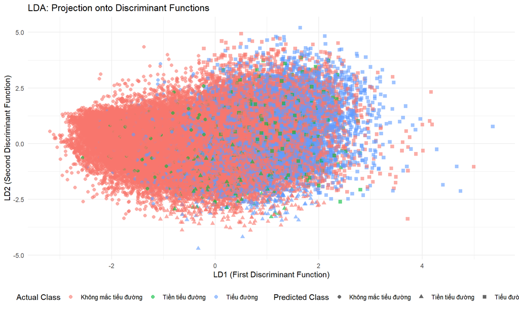

```r
# Chiếu dữ liệu lên không gian LD1-LD2
lda_values <- predict(lda_model_balanced, newdata = test_data)

lda_plot_data <- data.frame(
  LD1 = lda_values$x[, 1],
  LD2 = lda_values$x[, 2],
  Actual = test_data$diabetes_012,
  Predicted = lda_values$class
)

ggplot(lda_plot_data, aes(x = LD1, y = LD2, color = Actual, shape = Predicted)) +
  geom_point(alpha = 0.6, size = 2) +
  labs(title = "LDA: Projection onto Discriminant Functions",
       x = "LD1 (First Discriminant Function)",
       y = "LD2 (Second Discriminant Function)",
       color = "Actual Class", shape = "Predicted Class") +
  theme_minimal() +
  theme(legend.position = "bottom")
```

## 6.3 XGBoost - Phương pháp học máy phi tham số

### 6.3.1 Tại sao chọn XGBoost sau LDA?

Như đã phân tích, các giả định quan trọng của LDA (đặc biệt **homogeneity of covariance**) bị vi phạm nghiêm trọng. **XGBoost** được chọn vì:

#### 6.3.1.1 Ưu điểm về Giả định:

1. **Không yêu cầu giả định phân phối**
   - LDA/MLR giả định Gaussian/linearity → dễ vi phạm
   - XGBoost là **phi tham số** → không cần giả định về phân phối
2. **Không yêu cầu homogeneity of covariance**
   - LDA yêu cầu các lớp có cùng ma trận covariance
   - XGBoost học cấu trúc riêng cho từng lớp qua tree splitting
3. **Học được ranh giới phi tuyến (non-linear decision boundaries)**
   - LDA/MLR chỉ tạo ranh giới tuyến tính
   - XGBoost kết hợp nhiều cây quyết định → ranh giới phức tạp

#### 6.3.1.2 Ưu điểm về Class Imbalance:

4. **Xử lý class imbalance tốt hơn qua sample weights**
   - MLR/LDA bias về lớp đa số dù dùng prior/weights
   - XGBoost điều chỉnh weights tại mỗi boosting iteration
5. **Robust với dữ liệu thực tế**
   - Tự động xử lý missing values (không có trong dataset này)
   - Không nhạy cảm với outliers như parametric models

#### 6.3.1.3 Ưu điểm về Diễn giải:

6. **Feature importance** dễ diễn giải
   - Gain-based importance: biến nào giảm loss nhiều nhất
   - Phù hợp với mục tiêu y sinh: tìm yếu tố nguy cơ quan trọng

### 6.3.2 Chuẩn bị dữ liệu

```r
# Chuyển đổi labels
train_labels <- as.numeric(train_data$diabetes_012) - 1
test_labels <- as.numeric(test_data$diabetes_012) - 1

# Feature matrix
train_features <- as.matrix(train_data[, -which(names(train_data) == "diabetes_012")])
test_features <- as.matrix(test_data[, -which(names(test_data) == "diabetes_012")])

# Class weights
class_counts <- table(train_labels)
total_samples <- length(train_labels)
n_classes <- length(class_counts)

class_weights <- total_samples / (n_classes * class_counts)
sample_weights <- sapply(train_labels, function(label) {
  class_weights[as.character(label)]
})

# Tăng weight cho Prediabetes và Diabetes
sample_weights[train_labels == 1] <- sample_weights[train_labels == 1] * 1.5
sample_weights[train_labels == 2] <- sample_weights[train_labels == 2] * 1.4

# DMatrix
dtrain <- xgb.DMatrix(data = train_features, label = train_labels,
                      weight = sample_weights)
dtest <- xgb.DMatrix(data = test_features, label = test_labels)
```

### 6.3.3 Training XGBoost

```r
# Parameters
params <- list(
  objective = "multi:softprob",
  num_class = 3,
  eval_metric = "mlogloss",
  eta = 0.05,
  max_depth = 4,
  subsample = 0.7,
  colsample_bytree = 0.7,
  min_child_weight = 0.5,
  gamma = 0.1,
  alpha = 0.1,
  lambda = 1
)

# Cross-validation
set.seed(2024)
xgb_cv <- xgb.cv(
  params = params,
  data = dtrain,
  nrounds = 300,
  nfold = 5,
  early_stopping_rounds = 30,
  verbose = 0,
  stratified = TRUE
)

best_nrounds <- xgb_cv$best_iteration
if (is.null(best_nrounds) || length(best_nrounds) == 0) {
  best_nrounds <- nrow(xgb_cv$evaluation_log)
}

cat("Optimal number of rounds:", best_nrounds, "\n")
```

```
## Optimal number of rounds: 175
```

```r
# Train final model
set.seed(2024)
xgb_model <- xgb.train(
  params = params,
  data = dtrain,
  nrounds = best_nrounds,
  verbose = 0
)
```

### 6.3.4 Prediction và Evaluation

```r
# Predict
xgb_probs_original <- predict(xgb_model, dtest, reshape = TRUE)
xgb_predictions <- apply(xgb_probs_original, 1, which.max) - 1

# Convert to factor
test_labels_factor <- factor(test_labels, levels = c(0, 1, 2),
                              labels = c("Không mắc tiểu đường",
                                       "Tiền tiểu đường", "Tiểu đường"))
xgb_pred_factor <- factor(xgb_predictions, levels = c(0, 1, 2),
                          labels = c("Không mắc tiểu đường",
                                   "Tiền tiểu đường", "Tiểu đường"))

# Confusion matrix
xgb_conf_matrix <- confusionMatrix(xgb_pred_factor, test_labels_factor)

cat("=== XGBOOST RESULTS ===\n")
```

```
## === XGBOOST RESULTS ===
```

```r
print(xgb_conf_matrix$table)
```

```
##                       Reference
## Prediction             Không mắc tiểu đường Tiền tiểu đường Tiểu đường
##   Không mắc tiểu đường                32973             225        847
##   Tiền tiểu đường                     20499             642       3560
##   Tiểu đường                          10638             522       6196
```

```r
cat("\nSensitivity:\n")
```

```
##
## Sensitivity:
```

```r
print(round(xgb_conf_matrix$byClass[, "Sensitivity"], 4))
```

```
## Class: Không mắc tiểu đường      Class: Tiền tiểu đường
##                      0.5143                      0.4622
##           Class: Tiểu đường
##                      0.5844
```

### 6.3.5 ROC Curves - XGBoost

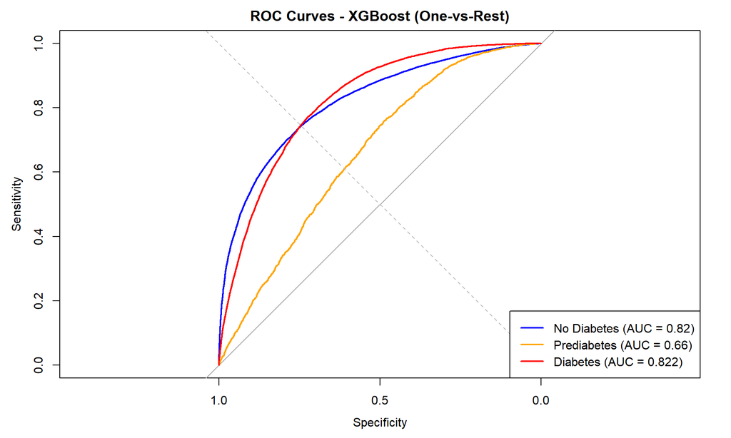

```r
# Binary labels
test_binary_0_xgb <- ifelse(test_labels == 0, 1, 0)
test_binary_1_xgb <- ifelse(test_labels == 1, 1, 0)
test_binary_2_xgb <- ifelse(test_labels == 2, 1, 0)

# ROC curves
roc_0_xgb <- roc(test_binary_0_xgb, xgb_probs_original[, 1], quiet = TRUE)
roc_1_xgb <- roc(test_binary_1_xgb, xgb_probs_original[, 2], quiet = TRUE)
roc_2_xgb <- roc(test_binary_2_xgb, xgb_probs_original[, 3], quiet = TRUE)

# Plot
plot(roc_0_xgb, col = "blue", lwd = 2,
     main = "ROC Curves - XGBoost (One-vs-Rest)")
plot(roc_1_xgb, col = "orange", lwd = 2, add = TRUE)
plot(roc_2_xgb, col = "red", lwd = 2, add = TRUE)
abline(a = 0, b = 1, lty = 2, col = "gray")
legend("bottomright",
       legend = c(
         paste0("No Diabetes (AUC = ", round(auc(roc_0_xgb), 3), ")"),
         paste0("Prediabetes (AUC = ", round(auc(roc_1_xgb), 3), ")"),
         paste0("Diabetes (AUC = ", round(auc(roc_2_xgb), 3), ")")
       ),
       col = c("blue", "orange", "red"),
       lwd = 2)
```

### 6.3.6 Feature Importance

```r
# Lấy feature importance
importance_matrix <- xgb.importance(
  feature_names = colnames(train_features),
  model = xgb_model
)

cat("=== TOP 15 MOST IMPORTANT FEATURES ===\n")
```

```
## === TOP 15 MOST IMPORTANT FEATURES ===
```

```r
kable(importance_matrix[1:15, c("Feature", "Gain")],
      caption = "Top 15 Features - XGBoost",
      digits = 4)
```

Top 15 Features - XGBoost

| Feature | Gain |
| --- | --- |
| gen_hlth | 0.2484 |
| high_bp | 0.1562 |
| bmi | 0.1531 |
| age | 0.1514 |
| high_chol | 0.0699 |
| income | 0.0481 |
| ment_hlth | 0.0259 |
| phys_hlth | 0.0248 |
| education | 0.0241 |
| heart_diseaseor_attack | 0.0223 |
| diff_walk | 0.0189 |
| hvy_alcohol_consump | 0.0148 |
| sex | 0.0140 |
| phys_activity | 0.0073 |
| stroke | 0.0068 |

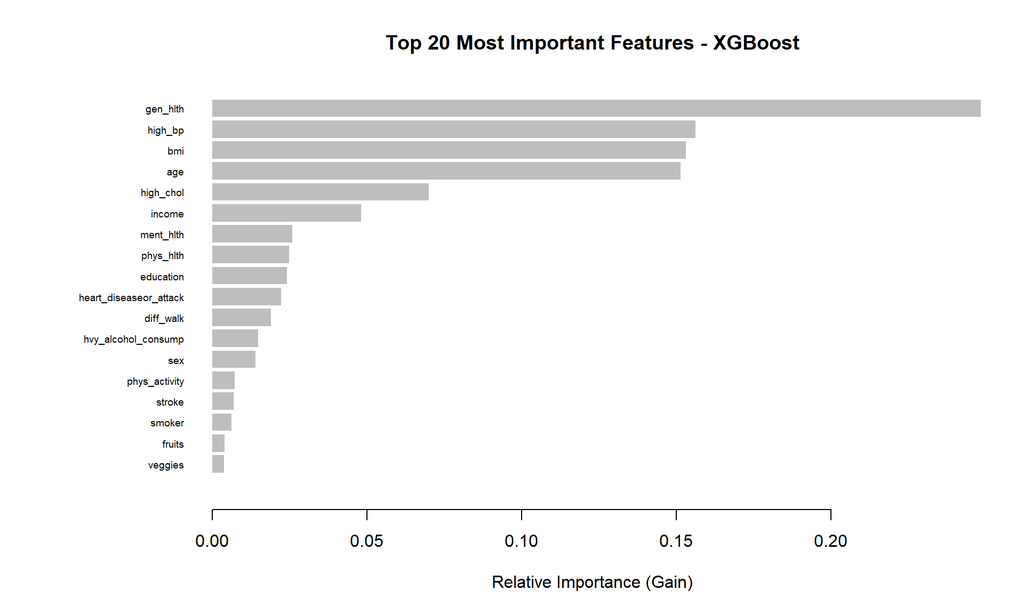

```r
# Visualize
xgb.plot.importance(importance_matrix[1:20, ],
                    main = "Top 20 Most Important Features - XGBoost",
                    xlab = "Relative Importance (Gain)")
```

# 7 So sánh và đánh giá mô hình

## 7.1 So sánh Performance Metrics

```r
# Thu thập metrics
mlr_overall_acc <- conf_hybrid_mlr$overall["Accuracy"]
mlr_sens <- conf_hybrid_mlr$byClass[, "Sensitivity"]
mlr_prec <- conf_hybrid_mlr$byClass[, "Pos Pred Value"]

lda_overall_acc <- conf_matrix_balanced$overall["Accuracy"]
lda_sens <- conf_matrix_balanced$byClass[, "Sensitivity"]
lda_prec <- conf_matrix_balanced$byClass[, "Pos Pred Value"]

xgb_overall_acc <- xgb_conf_matrix$overall["Accuracy"]
xgb_sens <- xgb_conf_matrix$byClass[, "Sensitivity"]
xgb_prec <- xgb_conf_matrix$byClass[, "Pos Pred Value"]

# Bảng so sánh
comparison_table <- data.frame(
  Metric = c("Overall Accuracy",
             "Sensitivity - No_Diabetes",
             "Sensitivity - Prediabetes",
             "Sensitivity - Diabetes",
             "Precision - No_Diabetes",
             "Precision - Prediabetes",
             "Precision - Diabetes",
             "AUC - No_Diabetes",
             "AUC - Prediabetes",
             "AUC - Diabetes"),

  MLR_Hybrid = c(
    round(mlr_overall_acc, 4),
    round(mlr_sens[1], 4),
    round(mlr_sens[2], 4),
    round(mlr_sens[3], 4),
    round(mlr_prec[1], 4),
    round(mlr_prec[2], 4),
    round(mlr_prec[3], 4),
    round(auc(roc_0_mlr), 4),
    round(auc(roc_1_mlr), 4),
    round(auc(roc_2_mlr), 4)
  ),

  LDA_Balanced = c(
    round(lda_overall_acc, 4),
    round(lda_sens[1], 4),
    round(lda_sens[2], 4),
    round(lda_sens[3], 4),
    round(lda_prec[1], 4),
    round(lda_prec[2], 4),
    round(lda_prec[3], 4),
    round(auc(roc_0), 4),
    round(auc(roc_1), 4),
    round(auc(roc_2), 4)
  ),

  XGBoost = c(
    round(xgb_overall_acc, 4),
    round(xgb_sens[1], 4),
    round(xgb_sens[2], 4),
    round(xgb_sens[3], 4),
    round(xgb_prec[1], 4),
    round(xgb_prec[2], 4),
    round(xgb_prec[3], 4),
    round(auc(roc_0_xgb), 4),
    round(auc(roc_1_xgb), 4),
    round(auc(roc_2_xgb), 4)
  )
)

kable(comparison_table,
      caption = "Bảng so sánh chi tiết 3 mô hình",
      row.names = FALSE,
      align = c("l", "c", "c", "c"))
```

Bảng so sánh chi tiết 3 mô hình

| Metric | MLR_Hybrid | LDA_Balanced | XGBoost |
| --- | --- | --- | --- |
| Overall Accuracy | 0.6381 | 0.6371 | 0.5231 |
| Sensitivity - No_Diabetes | 0.6377 | 0.6654 | 0.5143 |
| Sensitivity - Prediabetes | 0.1929 | 0.3499 | 0.4622 |
| Sensitivity - Diabetes | 0.6990 | 0.5036 | 0.5844 |
| Precision - No_Diabetes | 0.9531 | 0.9495 | 0.9685 |
| Precision - Prediabetes | 0.0265 | 0.0303 | 0.0260 |
| Precision - Diabetes | 0.3211 | 0.3525 | 0.3570 |
| AUC - No_Diabetes | 0.8110 | 0.8124 | 0.8200 |
| AUC - Prediabetes | 0.6620 | 0.6667 | 0.6603 |
| AUC - Diabetes | 0.8156 | 0.8104 | 0.8222 |

## 7.2 Visualization - Sensitivity Comparison

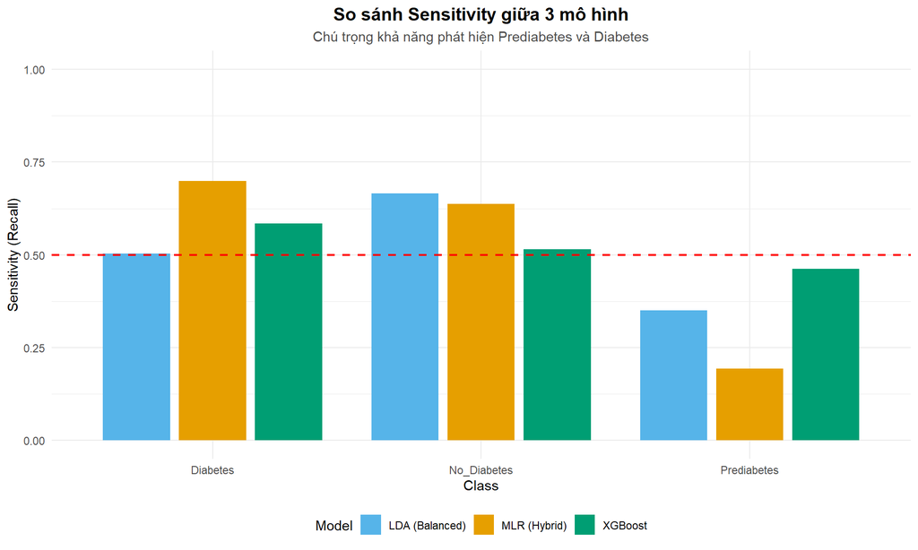

```r
sensitivity_comparison_all <- data.frame(
  Class = rep(c("No_Diabetes", "Prediabetes", "Diabetes"), each = 3),
  Model = rep(c("MLR (Hybrid)", "LDA (Balanced)", "XGBoost"), 3),
  Sensitivity = c(
    mlr_sens[1], lda_sens[1], xgb_sens[1],
    mlr_sens[2], lda_sens[2], xgb_sens[2],
    mlr_sens[3], lda_sens[3], xgb_sens[3]
  )
)

ggplot(sensitivity_comparison_all, aes(x = Class, y = Sensitivity, fill = Model)) +
  geom_bar(stat = "identity", position = position_dodge(width = 0.85),
           width = 0.75) +
  geom_hline(yintercept = 0.5, linetype = "dashed", color = "red", size = 0.8) +
  scale_fill_manual(values = c("MLR (Hybrid)" = "#E69F00",
                               "LDA (Balanced)" = "#56B4E9",
                               "XGBoost" = "#009E73")) +
  labs(title = "So sánh Sensitivity giữa 3 mô hình",
       subtitle = "Chú trọng khả năng phát hiện Prediabetes và Diabetes",
       x = "Class", y = "Sensitivity (Recall)", fill = "Model") +
  ylim(0, 1) +
  theme_minimal() +
  theme(plot.title = element_text(hjust = 0.5, size = 14, face = "bold"),
        plot.subtitle = element_text(hjust = 0.5, size = 11, color = "gray30"),
        legend.position = "bottom")
```

## 7.3 Visualization - AUC Comparison

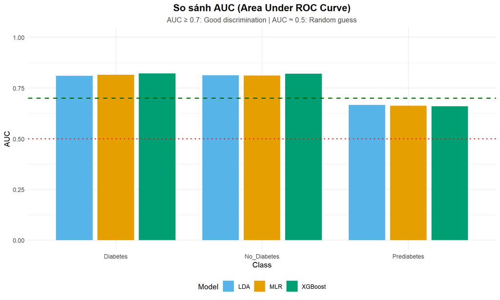

```r
auc_comparison_all <- data.frame(
  Class = rep(c("No_Diabetes", "Prediabetes", "Diabetes"), each = 3),
  Model = rep(c("MLR", "LDA", "XGBoost"), 3),
  AUC = c(
    auc(roc_0_mlr), auc(roc_0), auc(roc_0_xgb),
    auc(roc_1_mlr), auc(roc_1), auc(roc_1_xgb),
    auc(roc_2_mlr), auc(roc_2), auc(roc_2_xgb)
  )
)

ggplot(auc_comparison_all, aes(x = Class, y = AUC, fill = Model)) +
  geom_bar(stat = "identity", position = position_dodge(width = 0.85),
           width = 0.75) +
  geom_hline(yintercept = 0.7, linetype = "dashed", color = "darkgreen",
             size = 0.8) +
  geom_hline(yintercept = 0.5, linetype = "dotted", color = "red", size = 0.8) +
  scale_fill_manual(values = c("MLR" = "#E69F00",
                               "LDA" = "#56B4E9",
                               "XGBoost" = "#009E73")) +
  labs(title = "So sánh AUC (Area Under ROC Curve)",
       subtitle = "AUC ≥ 0.7: Good discrimination | AUC ≈ 0.5: Random guess",
       x = "Class", y = "AUC", fill = "Model") +
  ylim(0, 1) +
  theme_minimal() +
  theme(plot.title = element_text(hjust = 0.5, size = 14, face = "bold"),
        plot.subtitle = element_text(hjust = 0.5, size = 10, color = "gray30"),
        legend.position = "bottom")
```

# 8 Kết luận và khuyến nghị

## 8.1 Tóm tắt kết quả

### 8.1.1 Nhận xét so sánh 3 mô hình:

**1. Khả năng phát hiện Diabetes:**  
MLR (Hybrid) cho Sensitivity cao nhất, tiếp theo là XGBoost và LDA. Điều này cho thấy Logistic Regression tận dụng tốt các biến tuyến tính để nhận diện nhóm đã mắc tiểu đường.

**2. Khả năng phát hiện Prediabetes:**  
XGBoost đạt Sensitivity cao nhất trong 3 mô hình, trong khi LDA và đặc biệt MLR gặp khó khăn. Điều này phản ánh ưu thế của mô hình phi tuyến trong việc học các ranh giới phức tạp của nhóm tiền tiểu đường.

**4. So sánh AUC:**  
- Với các lớp **No_Diabetes** và **Diabetes**, cả ba mô hình đều đạt AUC > 0.8, thể hiện khả năng phân biệt tốt. - Riêng **Prediabetes**, AUC của cả ba mô hình thấp hơn (~0.65–0.70), cho thấy đây là lớp khó phân biệt nhất do đặc trưng chồng lấn.

### 8.1.2 Kết luận tổng hợp:

- **LDA**: Ổn định, dễ diễn giải, phù hợp làm mô hình baseline.
- **Logistic Regression (MLR)**: Mạnh trong phát hiện Diabetes, nhưng yếu với Prediabetes.
- **XGBoost**: Cân bằng tốt nhất giữa các lớp, đặc biệt có lợi thế khi phát hiện Prediabetes.

## 8.2 Khuyến nghị

**Trong bối cảnh y sinh và sàng lọc sớm:**

1. **XGBoost** là lựa chọn phù hợp nhất do khả năng phát hiện Prediabetes tốt hơn - nhóm có ý nghĩa quan trọng trong phòng ngừa tiến triển bệnh.
2. **LDA/MLR** vẫn hữu ích cho phân tích diễn giải và so sánh, giúp hiểu rõ các yếu tố nguy cơ.
3. **Các yếu tố quan trọng nhất** cần theo dõi:
   - GenHlth (Sức khỏe tổng quát)
   - BMI (Chỉ số khối cơ thể)
   - HighBP (Huyết áp cao)
   - HighChol (Cholesterol cao)
   - Age (Tuổi tác)
4. **Hướng phát triển tiếp theo:**
   - Thử nghiệm các phương pháp ensemble khác
   - Tối ưu hóa threshold cho từng use case cụ thể
   - Phân tích chi tiết các ca false negative/positive
   - Kết hợp với dữ liệu lâm sàng bổ sung